# Momentum in the MLB 2020

Anthony Fernandez

2025-05-29

```r
devtools::install_github("billpetti/baseballr")

library(baseballr)
library(dplyr)
library(purrr)
library(lubridate)
library(tidyverse)


# Load required packages
#install.packages("data.table")  # Only run if needed
library(data.table)
library(dplyr)
library(purrr)
```

```r
# New safer downloader
get_statcast_data_weekly <- function(start_date, end_date) {
  url <- paste0(
    "https://baseballsavant.mlb.com/statcast_search/csv?all=true",
    "&hfPT=&hfAB=&hfBBT=&hfPR=&hfZ=&stadium=&hfBBL=&hfNewZones=&hfGT=R%7CPO%7CS%7C",
    "&hfC&hfSit=&hfOuts=&opponent=&pitcher_throws=&batter_stands=",
    "&hfSA=&player_type=batter&hfInfield=&team=&position=&hfOutfield=",
    "&hfRO=&home_road=&game_date_gt=", start_date,
    "&game_date_lt=", end_date,
    "&group_by=name&sort_col=pitches&player_event_sort=h_launch_speed",
    "&sort_order=desc&type=details"
  )

  message(paste("Downloading:", start_date, "to", end_date))
  tryCatch({
    fread(url, showProgress = FALSE, fill = TRUE)
  }, error = function(e) {
    message("Failed:", e$message)
    NULL
  })
}
```

```r
# Define weekly ranges
dates_2020 <- data.frame(
  start = c("2020-07-23", "2020-07-30", "2020-08-06", "2020-08-13", "2020-08-20", "2020-08-27", "2020-09-03", "2020-09-10", "2020-09-17", "2020-09-24"),
  end   = c("2020-07-29", "2020-08-05", "2020-08-12", "2020-08-19", "2020-08-26", "2020-09-02", "2020-09-09", "2020-09-16", "2020-09-23", "2020-09-27")
)

# Download in chunks and combine
#statcast_2020 <- purrr::map2_dfr(dates_2020$start, dates_2020$end, get_statcast_data_weekly)

# Save the result
#saveRDS(statcast_2020, "statcast_2020_full.rds")

statcast_2020 <- readRDS("statcast_2020_full.rds")
```

```r
#summary(statcast_2020)

cols_to_keep <- c(
  "game_pk",             # Game ID
  "game_date",           # Date of game
  "at_bat_number",       # Sequential number of PA in game
  "inning",              # Inning
  "inning_topbot",       # Top or Bottom of inning
  "batter",              # Batter ID
  "player_name",         # Batter name
  "events",              # Event result (e.g. 'single', 'groundout')
  "description",         # Useful for identifying completed PAs
  "home_team",           # Home team
  "away_team",           # Away team
  "bat_score",           # Score at the time
  "post_bat_score",      # Score after PA
  "home_score", "away_score", # Full context
  "pitch_number"         # Needed to make sure we're only using the final pitch of the PA
)

statcast_2020_clean <- statcast_2020 %>%
  select(all_of(cols_to_keep)) %>%
  filter(!is.na(events))  # Remove non-PA rows (e.g. pickoffs, warmups)

# Check result
glimpse(statcast_2020_clean)
```

```
## Rows: 241,141
## Columns: 16
## $ game_pk        <int> 630916, 630916, 630916, 630916, 630916, 630916, 630916,…
## $ game_date      <IDate> 2020-07-29, 2020-07-29, 2020-07-29, 2020-07-29, 2020-…
## $ at_bat_number  <int> 57, 57, 57, 57, 57, 57, 56, 56, 56, 56, 56, 58, 42, 55,…
## $ inning         <int> 8, 8, 8, 8, 8, 8, 8, 8, 8, 8, 8, 7, 6, 8, 6, 7, 6, 8, 7…
## $ inning_topbot  <chr> "Bot", "Bot", "Bot", "Bot", "Bot", "Bot", "Bot", "Bot",…
## $ batter         <int> 605233, 605233, 605233, 605233, 605233, 605233, 669289,…
## $ player_name    <chr> "Fisher, Derek", "Fisher, Derek", "Fisher, Derek", "Fis…
## $ events         <chr> "walk", "", "", "", "", "", "strikeout", "", "", "", ""…
## $ description    <chr> "blocked_ball", "ball", "ball", "ball", "swinging_strik…
## $ home_team      <chr> "TOR", "TOR", "TOR", "TOR", "TOR", "TOR", "TOR", "TOR",…
## $ away_team      <chr> "WSH", "WSH", "WSH", "WSH", "WSH", "WSH", "WSH", "WSH",…
## $ bat_score      <int> 0, 0, 0, 0, 0, 0, 0, 0, 0, 0, 0, 3, 0, 0, 0, 1, 0, 0, 1…
## $ post_bat_score <int> 0, 0, 0, 0, 0, 0, 0, 0, 0, 0, 0, 3, 0, 0, 0, 3, 0, 0, 1…
## $ home_score     <int> 0, 0, 0, 0, 0, 0, 0, 0, 0, 0, 0, 3, 2, 0, 2, 1, 2, 0, 1…
## $ away_score     <int> 0, 0, 0, 0, 0, 0, 0, 0, 0, 0, 0, 7, 0, 0, 0, 7, 0, 0, 7…
## $ pitch_number   <int> 6, 5, 4, 3, 2, 1, 5, 4, 3, 2, 1, 1, 2, 3, 1, 1, 4, 2, 1…
```

```r
unique(statcast_2020$events)
```

```
##  [1] "walk"                      ""
##  [3] "strikeout"                 "double"
##  [5] "field_out"                 "single"
##  [7] "home_run"                  "grounded_into_double_play"
##  [9] "field_error"               "force_out"
## [11] "hit_by_pitch"              "double_play"
## [13] "sac_fly"                   "fielders_choice_out"
## [15] "sac_bunt"                  "truncated_pa"
## [17] "triple"                    "catcher_interf"
## [19] "triple_play"               "fielders_choice"
## [21] "strikeout_double_play"     "sac_fly_double_play"
```

```r
# Keep only the final pitch of each at-bat (where event is not NA and last pitch_number per at_bat)
library(dplyr)

statcast_pa_2020 <- statcast_2020_clean %>%
  filter(!is.na(events), events != "") %>%
  group_by(game_pk, at_bat_number) %>%
  filter(pitch_number == max(pitch_number)) %>%
  ungroup()
```

```r
# Sort by game, inning, top/bot, and at-bat
statcast_pa_2020 <- statcast_pa_2020 %>%
  arrange(game_pk, inning, inning_topbot, at_bat_number) %>%
  group_by(game_pk, inning, inning_topbot) %>%
  mutate(
    prev_event = lag(events),
    prev_batter = lag(batter),
    momentum = ifelse(prev_event %in% c("single", "double", "triple", "home_run", "sac_fly"), 1, 0)
  ) %>%
  ungroup()
```

```r
# Calculate batting average with vs. without momentum
momentum_ba <- statcast_pa_2020 %>%
  filter(events %in% c(
    "single", "double", "triple", "home_run",
    "field_out", "strikeout", "grounded_into_double_play",
    "double_play", "strikeout_double_play",
    "fielders_choice", "force_out"
  )) %>%
  mutate(hit = ifelse(events %in% c("single", "double", "triple", "home_run"), 1, 0)) %>%
  group_by(momentum) %>%
  summarise(
    PA = n(),
    Hits = sum(hit),
    Batting_Average = mean(hit)
  )

print(momentum_ba)
```

```
## # A tibble: 2 × 4
##   momentum    PA  Hits Batting_Average
##      <dbl> <int> <dbl>           <dbl>
## 1        0 42046 10241           0.244
## 2        1 11579  2945           0.254
```

########Break Down by Team################## ############################################

```r
statcast_pa_2020 <- statcast_pa_2020 %>%
  mutate(batting_team = ifelse(inning_topbot == "Top", away_team, home_team))

statcast_pa_2020 <- statcast_pa_2020 %>%
  mutate(hit = ifelse(events %in% c("single", "double", "triple", "home_run"), 1, 0))
```

```r
library(dplyr)

team_momentum_ba <- statcast_pa_2020 %>%
 filter(events %in% c(
    "single", "double", "triple", "home_run",
    "field_out", "strikeout", "grounded_into_double_play",
    "double_play", "strikeout_double_play",
    "fielders_choice", "force_out"
  )) %>%
  group_by(batting_team, momentum) %>%
  summarise(
    PA = n(),
    Hits = sum(hit),
    Batting_Average = mean(hit),
    .groups = "drop"
  )
```

```r
library(tidyr)

team_comparison_20 <- team_momentum_ba %>%
  pivot_wider(
    names_from = momentum,
    values_from = c(PA, Hits, Batting_Average),
    names_prefix = "momentum_"
  ) %>%
  mutate(
    BA_Difference = Batting_Average_momentum_1 - Batting_Average_momentum_0
  ) %>%
  arrange(desc(BA_Difference))

# View top teams by momentum boost
print(team_comparison_20)
```

```
## # A tibble: 30 × 8
##    batting_team PA_momentum_0 PA_momentum_1 Hits_momentum_0 Hits_momentum_1
##    <chr>                <int>         <int>           <dbl>           <dbl>
##  1 DET                   1366           389             312             123
##  2 SEA                   1403           366             305              97
##  3 AZ                    1410           390             328             109
##  4 CHC                   1415           330             302              82
##  5 PIT                   1354           335             288              80
##  6 TOR                   1421           406             356             112
##  7 WSH                   1373           433             360             123
##  8 LAD                   1389           396             344             106
##  9 COL                   1458           453             372             124
## 10 BAL                   1403           424             358             115
## # ℹ 20 more rows
## # ℹ 3 more variables: Batting_Average_momentum_0 <dbl>,
## #   Batting_Average_momentum_1 <dbl>, BA_Difference <dbl>
```

```r
#write.csv(team_comparison_20, "team_comparison_20.csv", row.names = FALSE)
```

```r
# Total hits in cleaned dataset
sum(statcast_pa_2020$hit, na.rm = TRUE)
```

```
## [1] 13186
```

```r
# Total hits from your momentum breakdown
sum(team_comparison_20$Hits_momentum_0, na.rm = TRUE) +
sum(team_comparison_20$Hits_momentum_1, na.rm = TRUE)
```

```
## [1] 13186
```

The reason the total hits from the momentum breakdown (Hits_momentum_0 + Hits_momentum_1) don’t match official MLB hit totals is because my analysis only includes plate appearances with specific qualifying events (like hits, outs, and double plays), and excludes others like walks, hit-by-pitches, and sac bunts. Additionally, momentum can only be calculated when there’s a valid previous batter, so the first batter of each inning or game may be excluded. However, since my total hits from the filtered dataset match the combined momentum hits exactly (13,186), my momentum analysis is internally consistent and correctly reflects the subset of data I chose to study.

```r
# Filter valid at-bats and create the hit column
valid_pas <- statcast_pa_2020 %>%
  filter(events %in% c(
    "single", "double", "triple", "home_run",
    "field_out", "strikeout", "grounded_into_double_play",
    "double_play", "strikeout_double_play",
    "fielders_choice", "force_out"
  )) %>%
  mutate(hit = ifelse(events %in% c("single", "double", "triple", "home_run"), 1, 0))

# Run the t-test
t_test_result <- t.test(hit ~ momentum, data = valid_pas)

print(t_test_result)
```

```
##
##  Welch Two Sample t-test
##
## data:  hit by momentum
## t = -2.3643, df = 18242, p-value = 0.01807
## alternative hypothesis: true difference in means between group 0 and group 1 is not equal to 0
## 95 percent confidence interval:
##  -0.019704485 -0.001841882
## sample estimates:
## mean in group 0 mean in group 1
##       0.2435666       0.2543398
```

In this stage of my project, I used a Welch Two Sample t-test to compare batting averages in plate appearances that followed a successful hit or sac fly (momentum = 1) versus those that did not (momentum = 0). My code filtered out non-official at-bats and isolated only the events relevant to batting average, ensuring a clean comparison. The results showed that hitters in momentum situations had a batting average of .254 compared to .244 without momentum—a statistically significant difference with a p-value of 0.018. This suggests that, based on 2020 data, there is evidence that momentum may have a small but measurable impact on offensive performance in Major League Baseball.

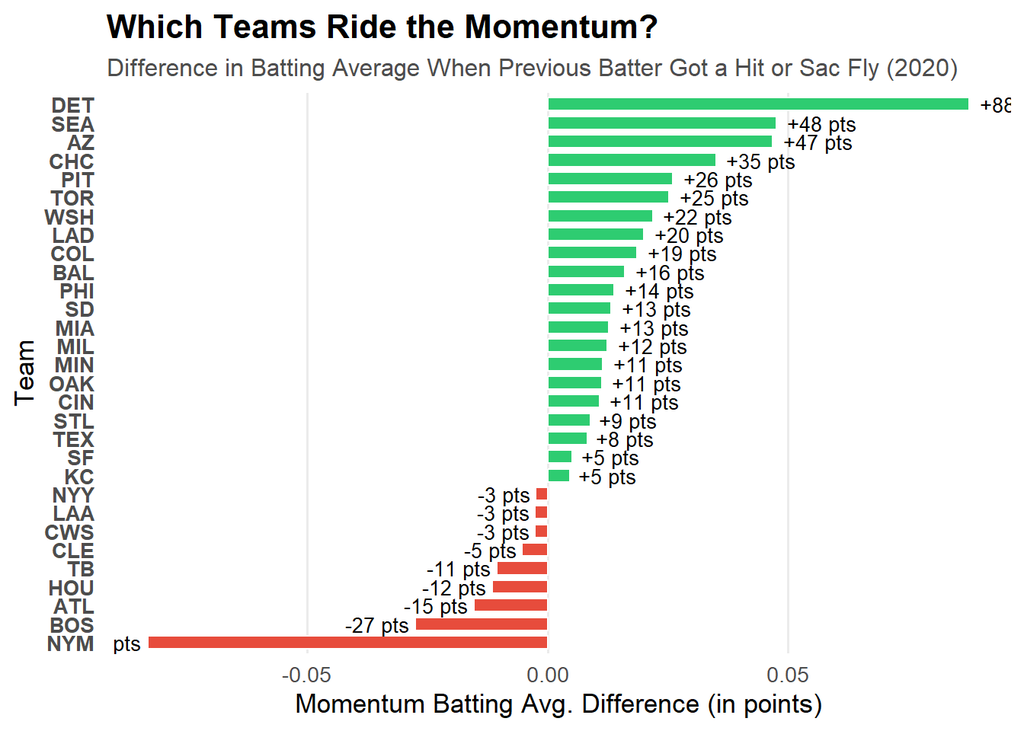

```r
library(ggplot2)

ggplot(team_comparison_20 %>% filter(!is.na(batting_team)),
       aes(x = reorder(batting_team, BA_Difference), y = BA_Difference, fill = BA_Difference > 0)) +
  geom_col(width = 0.7, color = "white", show.legend = FALSE) +
  scale_fill_manual(values = c("FALSE" = "#e74c3c", "TRUE" = "#2ecc71")) +
  geom_text(aes(label = sprintf("%+d pts", round(BA_Difference * 1000))),
            hjust = ifelse(team_comparison_20$BA_Difference > 0, -0.15, 1.1),
            size = 3.5, color = "black") +
  coord_flip() +
  labs(
    title = "Which Teams Ride the Momentum?",
    subtitle = "Difference in Batting Average When Previous Batter Got a Hit or Sac Fly (2020)",
    x = "Team",
    y = "Momentum Batting Avg. Difference (in points)"
  ) +
  theme_minimal(base_size = 13) +
  theme(
    plot.title = element_text(face = "bold", size = 16),
    plot.subtitle = element_text(color = "gray30", size = 12),
    panel.grid.major.y = element_blank(),
    panel.grid.minor = element_blank(),
    axis.text.y = element_text(face = "bold")
  )
```